# BayesODT

Chanmin Kim

7/11/2019

## Overview

The **BayesODT** package is to fit a Bayesian hierarchical model for ordinal classification data. The methods are detailed in the following paper

Kim et al. Measuring Rater Bias in Diagnostic Tests with Ordinal Ratings (submitted).

The citation for this package is

Chanmin Kim (2019). BayesODT: Bayesian Ordinal Diagnostic Test. R package version 1.0.

## Installation

The **BayesODT** package can be installed as follows

```
library(devtools)
install_github("lit777/BayesODT")
```

## Example

Call **BayesODT**

```r
library(BayesODT)
```

This package contains a simulated dataset, `simdata`, which can be loaded using data() function

```r
data("simdata")
str(simdata)
```

```
## List of 2
##  $ w: int [1:90, 1:50] 1 1 2 1 2 2 1 1 1 1 ...
##  $ D: int [1:90] 1 0 1 0 1 0 0 0 0 0 ...
```

`simdata` has the list format and includes two objects: `w`: 90 (patients) by 50 (raters) classification matrix; `D`: true disease statuses of 90 patients

## Fitting **BayesODT**

Before fitting the **BayesODT** model, initial values and hyper-prior parameter values need to be set.

```r
m <- dim(simdata$w)[1] # Num. of patients
n <- dim(simdata$w)[2] # Num. of raters
init <- list(z = matrix(1, nrow=m, ncol=n), z0 = rep(0, m), a = rnorm(n, 0, 1), b = rnorm(n, 0, 1), u = rnorm(m, 0, 1), A = c(-1,0,1,Inf))
prior <- list(mu_a = 0, tau_a = 1, mu_b = 0, tau_b = 1, delta = 5, gamma = 0.1, tau = 0.1, mu_u = 0, tau_u = 1)
```

When `A` is not specified in the `init` list, then **BayesODT** automatically estimates cut-points using the `clmm` function from the **ordinal** R package. Also, when `z0` is not specified in the `init` list, then the model for true disease status (i.e., Model 1 in the manuscript) is not used.

Run **BayesODT**

```r
fit <- BayesODT(w = simdata$w, D = simdata$D, init = init, prior = prior, n.iter = 4000, n.burnin = 2000, n.thin = 5, ROC =TRUE)
```

`n.iter`, `n.burnin`, `n.thin` specify the number of MCMC iterations, the number of burn-in iterations, thinning every `n.thin` iterations. `ROC=TRUE` when the ROC curve is needed; otherwise, turn off this feature for faster sampling.

Obtain the posterior means and 95% C.I.s of the parameters

```r
summary(fit)
```

[output not shown]

## Plotting Outputs

Plot the posterior means and 95% C.I.s of the parameters

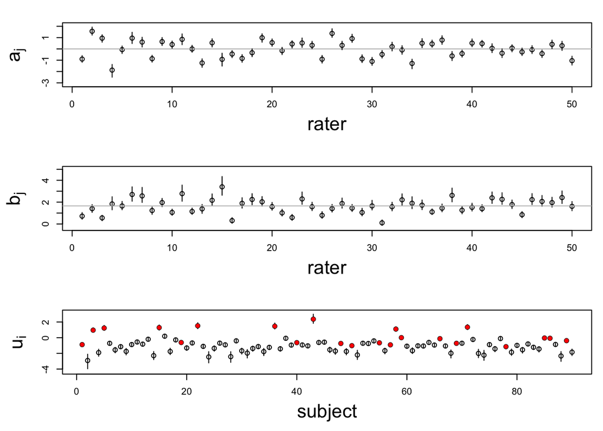

```r
plot_ABU(fit)
```

Plot ROC curves

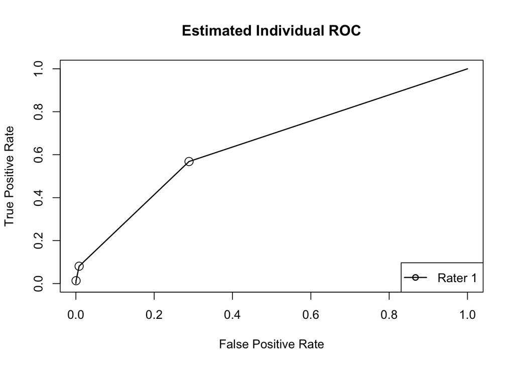

```r
plot_ROC(fit, method=c("Individual"), ind=1)
```

One `method` needs to be specified from `c("Individual", "ROC1", "ROC2", "Smoothed.ROC", "Smoothed.pROC", "pROC")`. For more details, see the manuscript. When `method="Individual` is specified, individual ID, `ind`, needs to be specified.

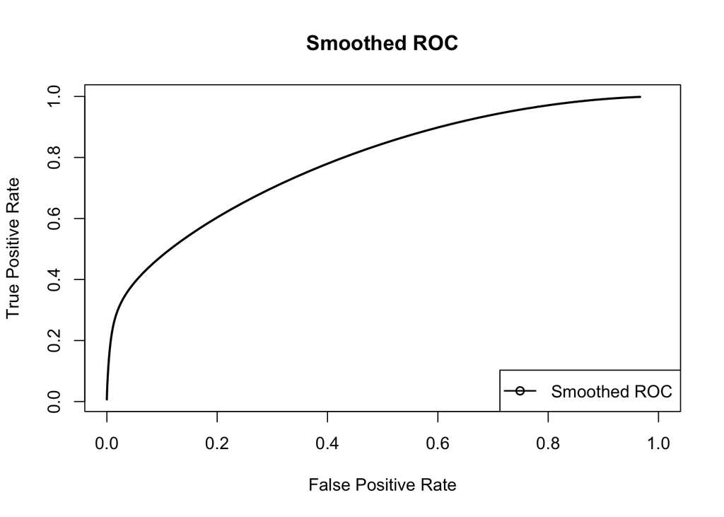

```r
plot_ROC(fit, method=c("Smoothed.ROC"))
```

## Goodness of Fit

To check goodness of fit of the model, one can compare the estimated marginal probability of W=k for each k to the corresponding empirical probability

```r
GoF(fit)
```

```
## $Estimated.Prob
## [1] 0.57182417 0.31533739 0.05773042 0.05510802
##
## $Estimated.Prob.ci
##            [,1]      [,2]       [,3]       [,4]
## 2.5%  0.5619698 0.3051430 0.05124444 0.05141724
## 97.5% 0.5819637 0.3263633 0.06295961 0.06050986
##
## $Empirical.Prob
##
##          1          2          3          4
## 0.57355556 0.31444444 0.05488889 0.05711111
```